# Milestone 3: Got Priors

Author

Heewon Yi, Noelle Haviland, Celia Carey

## Read in dataset

```r
library(readxl)
exchange <- read_excel("fredgraph.xlsx")

glimpse(exchange)
```

```
Rows: 1,350
Columns: 5
$ observation_date                           <dttm> 2020-02-03, 2020-02-04, 20…
$ `DFF (Federal Funds rate)`                 <dbl> 1.59, 1.59, 1.59, 1.59, 1.5…
$ `BRARECDM (Brazilian recession indicator)` <dbl> 1, 1, 1, 1, 1, 1, 1, 1, 1, …
$ `IHLIDXUS (Job Posting)`                   <dbl> 100.03, 100.06, 100.13, 100…
$ `DEXBZUS (exchange rate)`                  <dbl> 4.2411, 4.2405, 4.2567, 4.2…
```

Variable Standardization

```r
exchange <- exchange |>
  rename(FedFundsRate = "DFF (Federal Funds rate)",
         RecessionIndicator = "BRARECDM (Brazilian recession indicator)",
         JobPostings = "IHLIDXUS (Job Posting)",
         Reals_USD_Exchange = "DEXBZUS (exchange rate)") |>
  mutate(DFF_scaled = as.numeric(scale(FedFundsRate)),
         IHLIDXUS_scaled = as.numeric(scale(JobPostings)),
         DEXBZUS_scaled = as.numeric(scale(Reals_USD_Exchange)))

exchange_no_NA <- na.omit(exchange)
```

## Where is the data from?

The data is from the FRED website and we’re looking at how the Brazilian Reals to USD Spot Exchange Rate (https://fred.stlouisfed.org/series/DEXBZUS#, Data Updated: 2025-04-07) is affected by the:

- US Federal Funds Effective Rate, Percent, Daily, Not Seasonally Adjusted (https://fred.stlouisfed.org/series/DFF#, Data Updated: 2025-04-07)
- OECD based Recession Indicators for Brazil from the Peak through the Trough, +1 or 0, Daily, Not Seasonally Adjusted (https://fred.stlouisfed.org/series/BRARECDM#, Data Updated: 2022-11-10)
- Job Postings on Indeed in the United States, Index Feb, 1 2020=100, Daily, Seasonally Adjusted (https://fred.stlouisfed.org/series/IHLIDXUS#, Data Updated: 2025-04-08)

We first acquired data on April 3, but ultimately changed our minds and downloaded data on April 8 that we are planning to use. The data comes from the FRED website and is identified by an alphacode title (DEXBZUS, DFF, BRARECDM, and IHLIDXUS).

To format it in excel after downloading, we lined up the daily data that came in two sheets and placed the columns next to one another.

## Causal Diagram

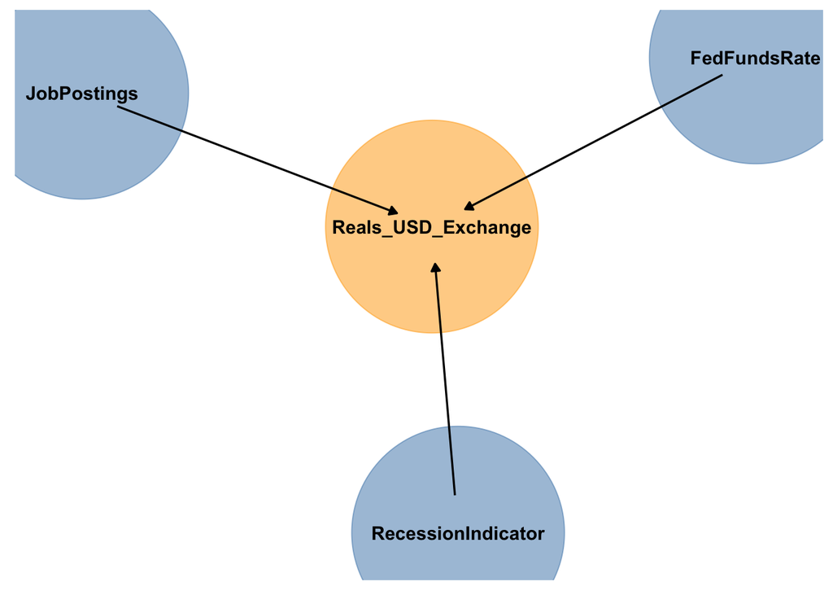

```r
causal_diagram <- dagitty("dag{
  FedFundsRate -> Reals_USD_Exchange;
  RecessionIndicator -> Reals_USD_Exchange;
  JobPostings -> Reals_USD_Exchange
}")

gg_dag(causal_diagram,
       size = 60,
       highlight = 'Reals_USD_Exchange')
```

## Causal Diagram Explanation

### Model Description

$$\text{Reals USD Exchange} \sim \text{Gamma distribution}(\alpha_{[i]}, \lambda)$$

$$\alpha_{[i]} = \beta_0+\beta_1*\text{FedFundsRate}+\beta_{\text{RecessionIndicator[i]}}+\beta_3*\text{JobPostings}$$

$$\beta_0\sim\text{Normal}(.76028,.65)$$

$$\beta_1\sim\text{Normal}(1.5, 2)$$

$$\beta_3\sim\text{Normal(125, 30)}$$

#### Rationale

Response Variable: Reals to USD Exchange Rate

- Predictor Variable: US Federal Funds rate ($\beta_1$) (https://www.grumpy-economist.com/p/do-higher-interest-rates-raise-the) An increase to the Federal Funds Rate should create an initial boost in the value of the dollar. With a higher value assigned to the USD, the exchange rate should increase. Therefore, this should be a positive relationship. The Federal Funds rate was originally data pulled from the FRED website that indicates an overnight interest rate between banks. On average this year, the Fed Funds rate has been around 4%, but we standardized our data so to account for this, we used 1.5 with a sd of 2 because occasionally, depending on other economic conditions, banks can lend other banks money at cost instead of at profit, though this is rather rare.
- Categorical Variable: Brazil Recession Indicator ($\beta_{\text{RecessionIndicator[i]}}$) During a recession, the money that used to be able to purchase, say two gallons of milk, will now only be able to purchase a quarter gallon. This indicates that the currency has become less valuable and should therefore even out in relation to another currency, hence a negative relationship to the exchange rate. We had to change the categorical values of this data to be “1” and “2” instead of “0” and “1”. As a result, we guessed that Brazil’s economy experience quite a bit of fluctuation and they are in a recession about half the time. With a standard deviation of 0.5, this expands to include both the recession and no recession values.
- Predictor Variable: US Job Postings According to the Federal Reserve Bank of New York, ($\beta_3$) “rise in employment strengthens the foreign exchange value of the dollar”. Therefore, also should be a positive relationship. Depending on how the job market is looking, there are a largely varying amount of jobs being posted on Indeed on a daily basis. According to the FRED, a loose average is around 100, but differs quite a bit, hence the larger standard deviation of 30.

## Prior Predictive Distribution

```r
n_sim <- 100

prior_pred_dists <- tibble(
  b0 = rnorm(n_sim, mean = .76028, sd = .65),
  b1 = rnorm(n_sim, mean = 1.5, sd = 2),
  b2 = rnorm(n_sim, mean = 0.5, sd = 0.5),
  b3 = rnorm(n_sim, mean = 125, sd = 30),
  sigma = rexp(n_sim, rate = 1),
  sim_number = c(1:n_sim)
  )

glimpse(prior_pred_dists)
```

```
Rows: 100
Columns: 6
$ b0         <dbl> 0.819525136, 0.862931733, 1.598636337, 1.655354082, 0.84211…
$ b1         <dbl> 3.2316926, 2.7128699, 0.9265247, 2.6940801, 3.2591922, 3.13…
$ b2         <dbl> 1.14660675, 0.73530348, 0.61340722, -0.12729090, 0.30462210…
$ b3         <dbl> 149.00772, 141.92803, 97.66652, 146.98139, 138.36563, 168.4…
$ sigma      <dbl> 0.30337780, 0.42804692, 0.36797481, 0.08840512, 0.13663151,…
$ sim_number <int> 1, 2, 3, 4, 5, 6, 7, 8, 9, 10, 11, 12, 13, 14, 15, 16, 17, …
```

```r
# Create prior predictive draws
prior_pred_dists <- prior_pred_dists |>
  mutate(
    mu = b0 + b1 + b2 + b3,
    y_sim = rgamma(n_sim, shape = mu^2 / sigma^2, rate = mu / sigma^2)
  )

glimpse(prior_pred_dists)
```

```
Rows: 100
Columns: 8
$ b0         <dbl> 0.819525136, 0.862931733, 1.598636337, 1.655354082, 0.84211…
$ b1         <dbl> 3.2316926, 2.7128699, 0.9265247, 2.6940801, 3.2591922, 3.13…
$ b2         <dbl> 1.14660675, 0.73530348, 0.61340722, -0.12729090, 0.30462210…
$ b3         <dbl> 149.00772, 141.92803, 97.66652, 146.98139, 138.36563, 168.4…
$ sigma      <dbl> 0.30337780, 0.42804692, 0.36797481, 0.08840512, 0.13663151,…
$ sim_number <int> 1, 2, 3, 4, 5, 6, 7, 8, 9, 10, 11, 12, 13, 14, 15, 16, 17, …
$ mu         <dbl> 154.20554, 146.23914, 100.80509, 151.20353, 142.77156, 172.…
$ y_sim      <dbl> 154.65484, 144.96053, 100.80017, 151.13842, 142.67755, 172.…
```

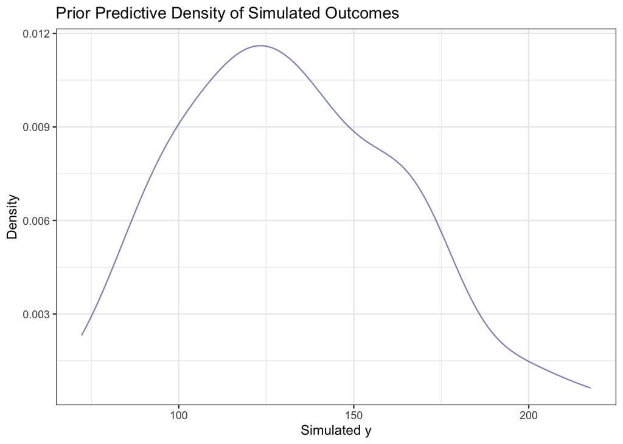

```r
gf_dens(~ y_sim, data = prior_pred_dists, color = "darkblue") |>
  gf_labs(
    title = "Prior Predictive Density of Simulated Outcomes",
    x = "Simulated y",
    y = "Density"
  ) +
  theme_bw()
```

### Citations

Cochrane, J. H. (2024, September 16). Do higher interest rates raise the exchange rate? The Grumpy Economist. https://www.grumpy-economist.com/p/do-higher-interest-rates-raise-the

Harris, E., & Zabka, N. M. (1995). The employment report and the dollar. Number, 1. https://doi.org/10.2139/ssrn.1001251

https://fred.stlouisfed.org/series/EXBZUS (took March 2025 average EXR to create B0)